# Deliverable 1

Carlson Smith

10/15/2020

# Introduction

In this project I will be studying climate change, deforestation, fires, and more with their effects on carbon emissions on earth. Using these predictions or data I will try to look to the future as well as find other correlations between the climate and how we live. The reason I’m interested in this field of research is because of the fires and reduction of snow in California along with the fear of how our actions might effect future generations. My parents have talked about how much snow there used to be in Tahoe, and how the fires have just gotten bigger.  
I want to know what we can change, and what causes the climate to warm and change over time

The Domains I will specifically be looking into are:

- Fire Emissions
- Fire frequency
- Temperature History
- Carbon Emissions
- Clean Energy
- Electrical Usage

# Data Sets

```r
co2.data <- read_csv("owid-co2-data.xlsx.csv")
```

co2.data comes from https://github.com/owid/co2-data that is maintained by Our World in Data. It is updated regularly and includes data on CO2 emissions along with other helpful metrics. The original data set has a few more continuous variables that I didn’t think I would need for what I want to look at.

The categorical variables for co2.data are:

- iso_code - ISO 3166-1 alpha-3 – three-letter country codes
- country - Geographic location
- year - Year of observation

The continuous variables for co2.data are:

- co2 - Annual production-based emissions of carbon dioxide (CO2), measured in million tonnes per year.
- co2_growth_prct - Percentage change in CO2 emissions from one year relative to the previous year.
- co2_growth_abs - Annual change in CO2 emissions from one year relative to the previous year, measured in million tonnes.
- share_global_co2 - National or regional annual CO2 emissions, measured as a percentage of the global total
- cumulative_co2 - Cumulative emissions of CO2 from 1751 through to the given year, measured in million tonnes.
- share_global_cumulative_co2 - National or regional annual cumulative CO2 emissions, measured as a share of the global total
- cement_co2 - CO2 emissions from cement production, measured in million tonnes.
- coal_co2 - CO2 emissions from coal production, measured in million tonnes.
- flaring_co2 - CO2 emissions from gas flaring, measured in million tonnes.
- gas_co2 - CO2 emissions from gas production, measured in million tonnes.
- oil_co2 - CO2 emissions from oil production, measured in million tonnes.
- population - Total population
- gdp - Total real gross domestic product, inflation-adjusted

co2.data comes from Our World in Data and will have some limitations, but should be a very trustworthy source as it does come from a source with a good reputation. You also know that the website doesn’t make money off of what they do since it’s a .org site. The one downside of this data set is that they don’t split up co2 emissions to all the possible sources which means the countries actual co2 release could be different.

```r
tree.data <- read_csv("global_country_tree_cover_loss.csv")
```

tree.data comes from https://www.globalforestwatch.org that is made through a partnership with World Resources Institute. It is updated regularly and keeps track of the forests starting from around 2001. Since it’s hard to keep track of forests before the initial photos in 2001 were taken, the data is a little more limited to recent years.

The categorical variables for tree.data are:

- country - Geographic location
- threshold - Percent canopy cover levels

The continuous variables for tree.data are:

- area_ha - Hectares of tree cover
- extent_2000_ha - Hectares of tree cover in 2000
- extent_2010_ha - Hectares of tree cover in 2010
- gain_2000-2012_ha - From 2001 to 2012, hectares of tree cover gained
- tc_loss_ha_2001 - Hectares of tree cover loss for 2001
- All years in between show loss for different years
- tc_loss_ha_2019 - Hectares tree cover loss for 2019

tree.data is another organization who monitors the forests of our world with satellite data. Again, they are an .org so the website isn’t made to get money and the data they get is going to be quite accurate. Using high resolution satellite imagery to look at our forests is a great way to get a generic summary of how they’re doing without too much work.

One worry for this data set is that comparison between 2001-2009 and 2011-2019 is not supposed to be very accurate or show patterns. The authors of the data said to preform this with caution making me think that they are comparing new data to extent 2000 or extent 2010 to find the loss of tree cover. If comparing the two, tree growth and forest regrowth will have to be considered.

```r
fire.data <- read_csv("US_Fires.csv")
```

fire.data comes from https://www.nifc.gov/fireInfo/fireInfo_stats_totalFires.html. The data for this data set comes from the National Interagency Fire Center who handles multi agency corrdination for fire fighting in the United States. The data that it provides is a general summary of the US and the fires over years.

The categorical variables for fire.data are:

- Year - The year fire data relates to

The continuous variables for fire.data are:

- Fires - Number of fires
- Acres - Acres burned

fire.data does come from a .org and national agency, but I dont know how reliable it is going to be. I have never heard of this group until I was looking for data so I might run into issues later if I realize this data isn’t reliable.

Another worry with this data is there is a chance deforestation is the US and the acres burned are connected, but also who knows, more research is going to be needed to figure out if they track the similar areas.

```r
car.data <- read_csv("Annual_Emissions_per_Vehicle.csv")
electric.data <- read_csv("Electricity_Sources.csv")
```

car.data and electric.data is grabbed from https://afdc.energy.gov/vehicles/electric_emissions.html that breaks down the data into a pie chart and bar chart. This data source is to fill in some blanks of data in our previous data sets so we can better explore our questions

The categorical variables for car.data are:

- car_type - Style of engine for cars

The continuous variables for car.data are:

- pounds_of_c02 - pounds of co2 released by car over a year
- miles_driven - miles driven by car over a year

The categorical variables for electric.data are:

- electric_sources - Electric source for the grid

The continuous variables for electric.data are:

- percentage_grid - percentage of the grid supported by type of source

These two sets of data are from the United States Department of Energy who also listed where they got their estimations and data. The sources they used and the results of the summarization all come from quite trustworthy sources. Though the one downside of this data set is that it is only for the United States and not global.

# Data Prep and Analysis

co2.data has data that covers generic land regions that overlap with countries.  
This is just added up from each country in it so I figured by deleting the data that didn’t have an iso_code, we could remove some of this overlap. I’m also going to delete any data that doesn’t have co2 output since that’s what we really  
are about when looking at this data

```r
co2.data <- filter(co2.data, iso_code != is.na(iso_code), co2 > 0)
head(co2.data)
```

```
## # A tibble: 6 x 16
##   iso_code country  year   co2 co2_growth_prct co2_growth_abs share_global_co2
##   <chr>    <chr>   <dbl> <dbl>           <dbl>          <dbl>            <dbl>
## 1 AFG      Afghan~  1949 0.015           NA            NA                0
## 2 AFG      Afghan~  1950 0.084          475             0.07             0.001
## 3 AFG      Afghan~  1951 0.092            8.70          0.007            0.001
## 4 AFG      Afghan~  1952 0.092            0             0                0.001
## 5 AFG      Afghan~  1953 0.106           16             0.015            0.002
## 6 AFG      Afghan~  1954 0.106            0             0                0.002
## # ... with 9 more variables: cumulative_co2 <dbl>,
## #   share_global_cumulative_co2 <dbl>, cement_co2 <dbl>, coal_co2 <dbl>,
## #   flaring_co2 <dbl>, gas_co2 <dbl>, oil_co2 <dbl>, population <dbl>,
## #   gdp <dbl>
```

This graph shows the carbon emissions for countries based on the year, though the first time I tried this, it didn’t work since there were too many countries with very low carbon output to draw lines for each one. For ease of visualization, I’m going to set the co2 to above 100 million tonnes per year.

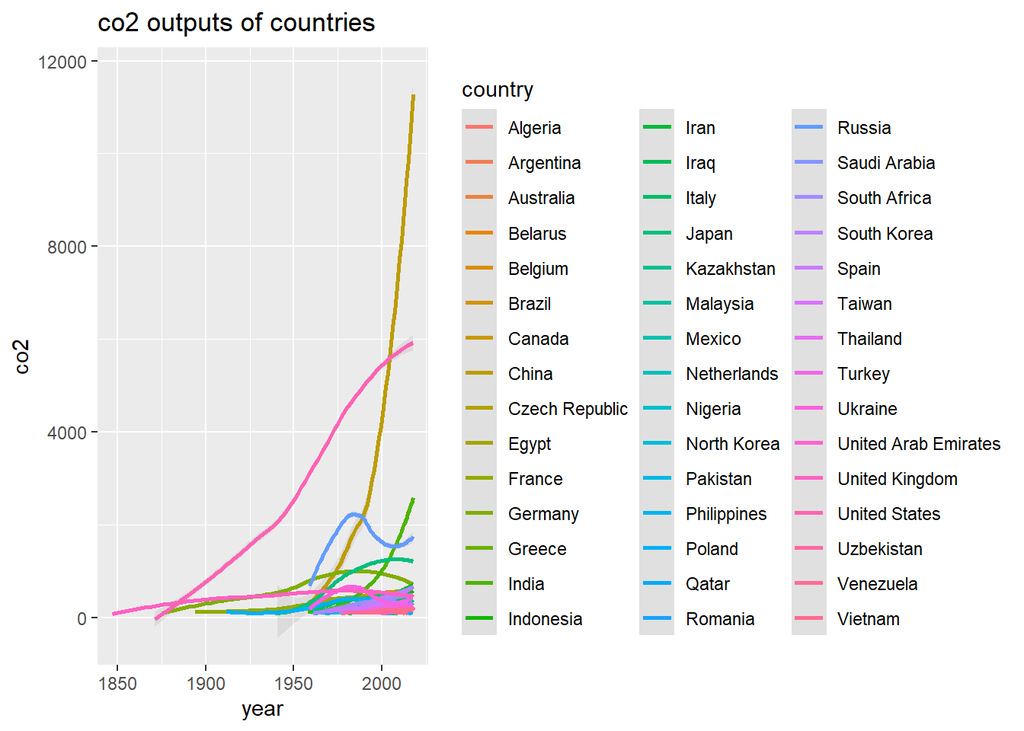

```r
ggplot(data = filter(co2.data, co2 > 100, country != "World"), mapping = aes(x=year, y=co2, color = country))+
  geom_smooth(alpha = 0.2)+
  ggtitle("co2 outputs of countries")
```

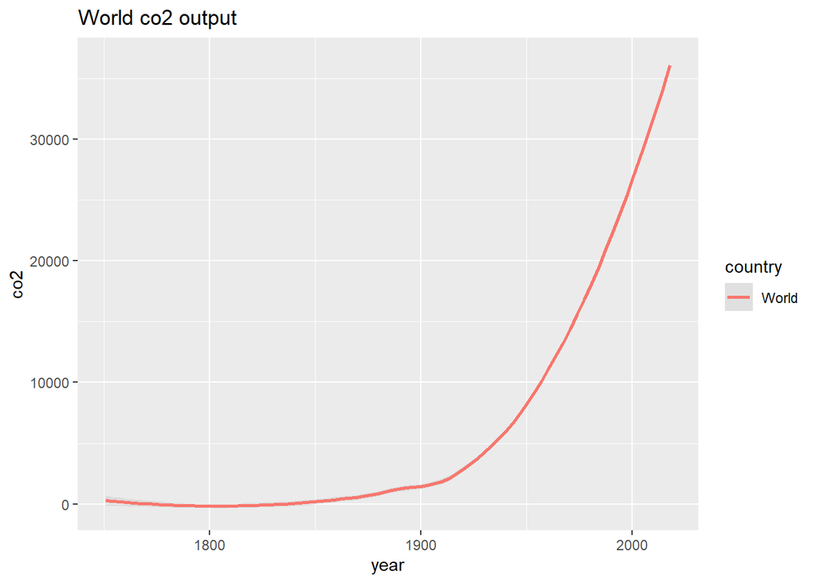

```r
ggplot(data = filter(co2.data, country == "World"), mapping = aes(x=year, y=co2, color = country))+
  geom_smooth(alpha = 0.2)+
  ggtitle("World co2 output")
```

You can see from this data set, the overall growth of co2 emissions and outputs with the World summary line. Admittedly there are too many countries to see all of this added up on the graph, but you can see the general idea with the visible lines. There are also lots more in the data set that are not put in the graph since we wouldn’t be able to graph each line, these are just the biggest emitters. Though you can see each line with their growth over the years, some moving faster than others.

```r
summary(co2.data)
```

```
##    iso_code           country               year           co2
##  Length:18439       Length:18439       Min.   :1751   Min.   :    0.00
##  Class :character   Class :character   1st Qu.:1950   1st Qu.:    0.52
##  Mode  :character   Mode  :character   Median :1975   Median :    4.39
##                                        Mean   :1965   Mean   :  171.67
##                                        3rd Qu.:1997   3rd Qu.:   33.09
##                                        Max.   :2018   Max.   :36572.75
##
##  co2_growth_prct     co2_growth_abs     share_global_co2  cumulative_co2
##  Min.   :-2835.714   Min.   :-847.729   Min.   :  0.000   Min.   :     -1.2
##  1st Qu.:   -1.097   1st Qu.:  -0.015   1st Qu.:  0.004   1st Qu.:      6.6
##  Median :    3.578   Median :   0.051   Median :  0.045   Median :     77.9
##  Mean   :   18.359   Mean   :   3.864   Mean   :  2.864   Mean   :   6259.4
##  3rd Qu.:   10.680   3rd Qu.:   0.869   3rd Qu.:  0.322   3rd Qu.:    770.6
##  Max.   :27336.247   Max.   :1543.508   Max.   :100.000   Max.   :1611817.1
##  NA's   :229         NA's   :214
##  share_global_cumulative_co2   cement_co2          coal_co2
##  Min.   :0.0000000           Min.   :   0.000   Min.   :    0.000
##  1st Qu.:0.0000000           1st Qu.:   0.000   1st Qu.:    0.110
##  Median :0.0000000           Median :   0.179   Median :    2.176
##  Mean   :0.0002734           Mean   :   5.591   Mean   :  110.922
##  3rd Qu.:0.0000000           3rd Qu.:   1.147   3rd Qu.:   16.693
##  Max.   :0.0100000           Max.   :1506.762   Max.   :15043.240
##                              NA's   :4215       NA's   :5362
##   flaring_co2         gas_co2            oil_co2            population
##  Min.   :  0.000   Min.   :  -0.007   Min.   :   -1.748   Min.   :2.000e+03
##  1st Qu.:  0.000   1st Qu.:   0.000   1st Qu.:    0.136   1st Qu.:1.308e+06
##  Median :  0.000   Median :   0.059   Median :    1.432   Median :5.198e+06
##  Mean   :  3.222   Mean   :  38.168   Mean   :   60.063   Mean   :4.858e+07
##  3rd Qu.:  0.275   3rd Qu.:   5.888   3rd Qu.:   10.681   3rd Qu.:1.612e+07
##  Max.   :402.003   Max.   :7485.188   Max.   :12425.536   Max.   :7.631e+09
##  NA's   :8779      NA's   :6582       NA's   :556         NA's   :350
##       gdp
##  Min.   :6.378e+07
##  1st Qu.:9.080e+09
##  Median :3.022e+10
##  Mean   :4.434e+11
##  3rd Qu.:1.230e+11
##  Max.   :1.066e+14
##  NA's   :5548
```

You can also see from this summary of co2.data that the mean of co2_growth_prct is on an upward trend even though the min occurrence is negative. Same thing with the co2_growth_abs.

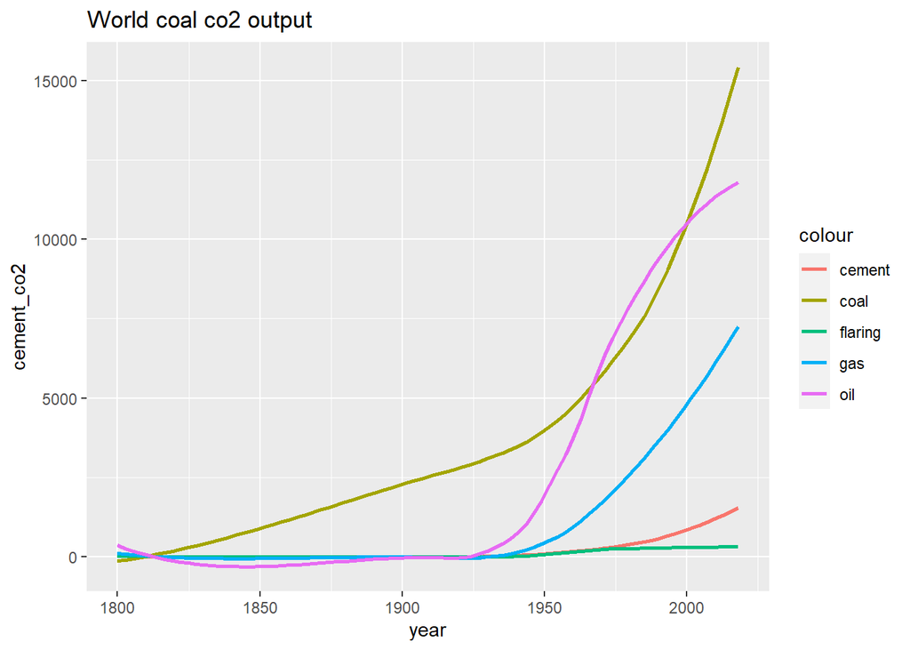

```r
ggplot()+
  geom_smooth(data = filter(co2.data, country == "World"), se = FALSE, mapping = aes(x=year, y=cement_co2, color='cement'))+
  geom_smooth(data = filter(co2.data, country == "World"), se = FALSE, mapping = aes(x=year, y=coal_co2, color='coal'))+
  geom_smooth(data = filter(co2.data, country == "World"), se = FALSE, mapping = aes(x=year, y=flaring_co2, color='flaring'))+
  geom_smooth(data = filter(co2.data, country == "World"), se = FALSE, mapping = aes(x=year, y=gas_co2, color='gas'))+
  geom_smooth(data = filter(co2.data, country == "World"), se = FALSE, mapping = aes(x=year, y=oil_co2, color='oil'))+
  ggtitle("World coal co2 output")
```

This graph splits up all the sources of co2 in the world to really show who is doing the most and what really needs to be fixed if we want to reduce our emissions. These could all be things fixed in the future to reverse the damage we have done so far.

```r
head(tree.data)
```

```
## # A tibble: 6 x 25
##   country threshold area_ha extent_2000_ha extent_2010_ha `gain_2000-2012~
##   <chr>       <dbl>   <dbl>          <dbl>          <dbl>            <dbl>
## 1 Afghan~        10  6.44e7         432115         126247              304
## 2 Afghan~        15  6.44e7         302660         106867              304
## 3 Afghan~        20  6.44e7         284357         105733              304
## 4 Afghan~        25  6.44e7         254867          72395              304
## 5 Afghan~        30  6.44e7         205791          71797              304
## 6 Afghan~        50  6.44e7         148430          46242              304
## # ... with 19 more variables: tc_loss_ha_2001 <dbl>, tc_loss_ha_2002 <dbl>,
## #   tc_loss_ha_2003 <dbl>, tc_loss_ha_2004 <dbl>, tc_loss_ha_2005 <dbl>,
## #   tc_loss_ha_2006 <dbl>, tc_loss_ha_2007 <dbl>, tc_loss_ha_2008 <dbl>,
## #   tc_loss_ha_2009 <dbl>, tc_loss_ha_2010 <dbl>, tc_loss_ha_2011 <dbl>,
## #   tc_loss_ha_2012 <dbl>, tc_loss_ha_2013 <dbl>, tc_loss_ha_2014 <dbl>,
## #   tc_loss_ha_2015 <dbl>, tc_loss_ha_2016 <dbl>, tc_loss_ha_2017 <dbl>,
## #   tc_loss_ha_2018 <dbl>, tc_loss_ha_2019 <dbl>
```

tree.date looks at all of the tree cover, and to make it a little easier to find patterns in the data, I’m going to cut down the canopy density percentage to 30% and up. The reason for cutting at 30% is that its the better visualization of tree loss, you can’t choose 100%, but you cant choose 10%, as acres lost at that point would do very little to the number of trees. Along with that, I’m going to rotate the data to make year a new variable so I can easily graph tree loss over the years as well as join co2 and trees later on.

```r
tree.30threshold <- filter(tree.data, threshold == 30)
names(tree.30threshold)[7] <- "2001"
names(tree.30threshold)[8] <- "2002"
names(tree.30threshold)[9] <- "2003"
names(tree.30threshold)[10] <- "2004"
names(tree.30threshold)[11] <- "2005"
names(tree.30threshold)[12] <- "2006"
names(tree.30threshold)[13] <- "2007"
names(tree.30threshold)[14] <- "2008"
names(tree.30threshold)[15] <- "2009"
names(tree.30threshold)[16] <- "2010"
names(tree.30threshold)[17] <- "2011"
names(tree.30threshold)[18] <- "2012"
names(tree.30threshold)[19] <- "2013"
names(tree.30threshold)[20] <- "2014"
names(tree.30threshold)[21] <- "2015"
names(tree.30threshold)[22] <- "2016"
names(tree.30threshold)[23] <- "2017"
names(tree.30threshold)[24] <- "2018"
names(tree.30threshold)[25] <- "2019"
tree.pivot <- pivot_longer(tree.30threshold,c('2001','2002','2003','2004','2005','2006','2007','2008','2009','2010','2011','2012','2013','2014','2015','2016','2017','2018','2019'),names_to = "year", values_to = "tc_loss_ha")
head(tree.pivot)
```

```
## # A tibble: 6 x 8
##   country threshold area_ha extent_2000_ha extent_2010_ha `gain_2000-2012~ year
##   <chr>       <dbl>   <dbl>          <dbl>          <dbl>            <dbl> <chr>
## 1 Afghan~        30  6.44e7         205791          71797              304 2001
## 2 Afghan~        30  6.44e7         205791          71797              304 2002
## 3 Afghan~        30  6.44e7         205791          71797              304 2003
## 4 Afghan~        30  6.44e7         205791          71797              304 2004
## 5 Afghan~        30  6.44e7         205791          71797              304 2005
## 6 Afghan~        30  6.44e7         205791          71797              304 2006
## # ... with 1 more variable: tc_loss_ha <dbl>
```

```r
summarize(tree.pivot, mean(tc_loss_ha))
```

```
## # A tibble: 1 x 1
##   `mean(tc_loss_ha)`
##                <dbl>
## 1            126616.
```

Though I couldn’t make a graph you can see the mean tc_loss_ha over all the years. I’m going to have to the size of this data and look at singular countries or make the data easier to look at some point. Maybe I could come up with a sum total to look at the world deforestation?

Using this pivot, we can combine with the co2 data with the years and countries that appear in both data sets. This gives us a generic and overarching data set with deforestation rates and co2 emissions. I’m going to filter as well since if I don’t want to join and have tree data being empty, I want the related years only, which is limited my tree.pivot which goes 2001-2019.

```r
tree.pivot$year <- as.double(tree.pivot$year)
tree.co2.data <- left_join(co2.data, tree.pivot) %>%
  filter(year > 2000)
head(tree.co2.data)
```

```
## # A tibble: 6 x 22
##   iso_code country  year   co2 co2_growth_prct co2_growth_abs share_global_co2
##   <chr>    <chr>   <dbl> <dbl>           <dbl>          <dbl>            <dbl>
## 1 AFG      Afghan~  2001 0.812            5.71          0.044            0.003
## 2 AFG      Afghan~  2002 1.06            31.0           0.252            0.004
## 3 AFG      Afghan~  2003 1.20            13.3           0.141            0.004
## 4 AFG      Afghan~  2004 0.908          -24.6          -0.297            0.003
## 5 AFG      Afghan~  2005 1.32            45.3           0.412            0.005
## 6 AFG      Afghan~  2006 1.64            24.5           0.323            0.005
## # ... with 15 more variables: cumulative_co2 <dbl>,
## #   share_global_cumulative_co2 <dbl>, cement_co2 <dbl>, coal_co2 <dbl>,
## #   flaring_co2 <dbl>, gas_co2 <dbl>, oil_co2 <dbl>, population <dbl>,
## #   gdp <dbl>, threshold <dbl>, area_ha <dbl>, extent_2000_ha <dbl>,
## #   extent_2010_ha <dbl>, `gain_2000-2012_ha` <dbl>, tc_loss_ha <dbl>
```

To take a peek for relations in the tree/co2 data set, I’m going to reduce it to just the USA where I can look at both the growth rates of deforestation and how much co2 we make

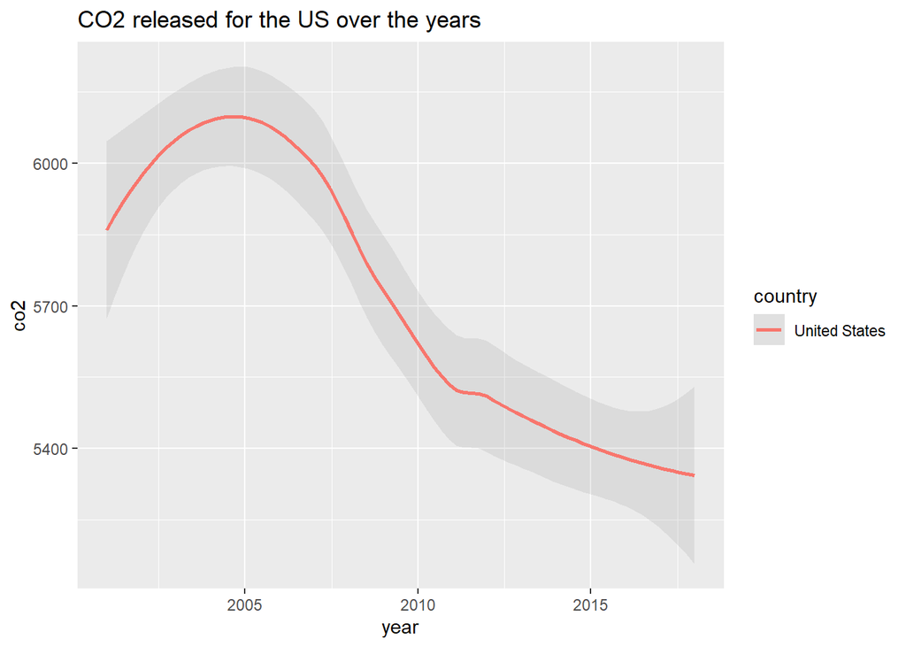

```r
ggplot(data = filter(tree.co2.data, iso_code == 'USA'), mapping = aes(x=year, y=co2, color = country))+
  geom_smooth(alpha = 0.2)+
  ggtitle("CO2 released for the US over the years")
```

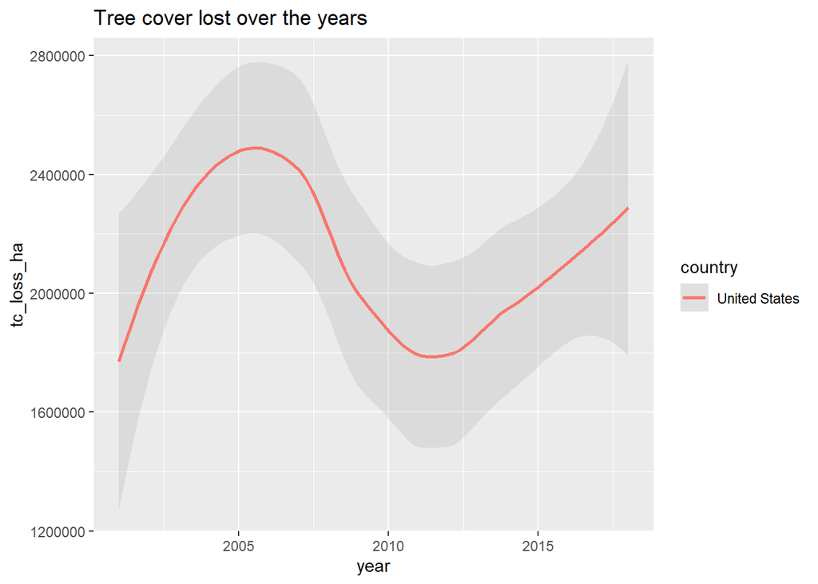

```r
ggplot(data = filter(tree.co2.data, iso_code == 'USA'), mapping = aes(x=year, y=tc_loss_ha, color = country))+
  geom_smooth(alpha = 0.2)+
  ggtitle("Tree cover lost over the years")
```

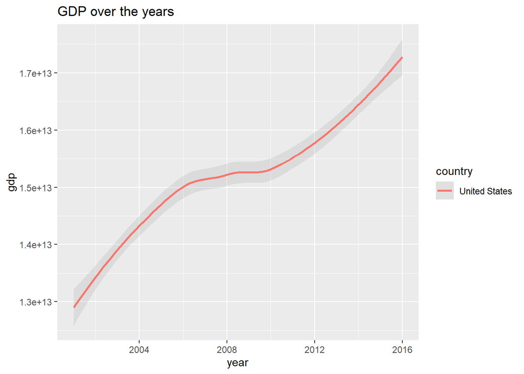

```r
ggplot(data = filter(tree.co2.data, iso_code == 'USA'), mapping = aes(x=year, y=gdp, color = country))+
  geom_smooth(alpha = 0.2)+
  ggtitle("GDP over the years")
```

```r
head(fire.data)
```

```
## # A tibble: 6 x 3
##    Year Fires    Acres
##   <dbl> <dbl>    <dbl>
## 1  2019 50477  4664364
## 2  2018 58083  8767492
## 3  2017 71499 10026086
## 4  2016 67743  5509995
## 5  2015 68151 10125149
## 6  2014 63312  3595613
```

```r
summary(fire.data)
```

```
##       Year          Fires            Acres
##  Min.   :1926   Min.   : 18229   Min.   : 1148409
##  1st Qu.:1949   1st Qu.: 78839   1st Qu.: 3413181
##  Median :1972   Median :115852   Median : 5568044
##  Mean   :1972   Mean   :124500   Mean   :12062963
##  3rd Qu.:1996   3rd Qu.:170808   3rd Qu.:15488500
##  Max.   :2019   Max.   :249370   Max.   :52266000
```

The Fire data for the US is mainly to see if there is a connection with the co2 emissions and rates of fire as well. There is a chance that deforestation reduces fires as well which could be something explored in the future as well. This could be explored further if I look into the Australian data with their recent mega fire.

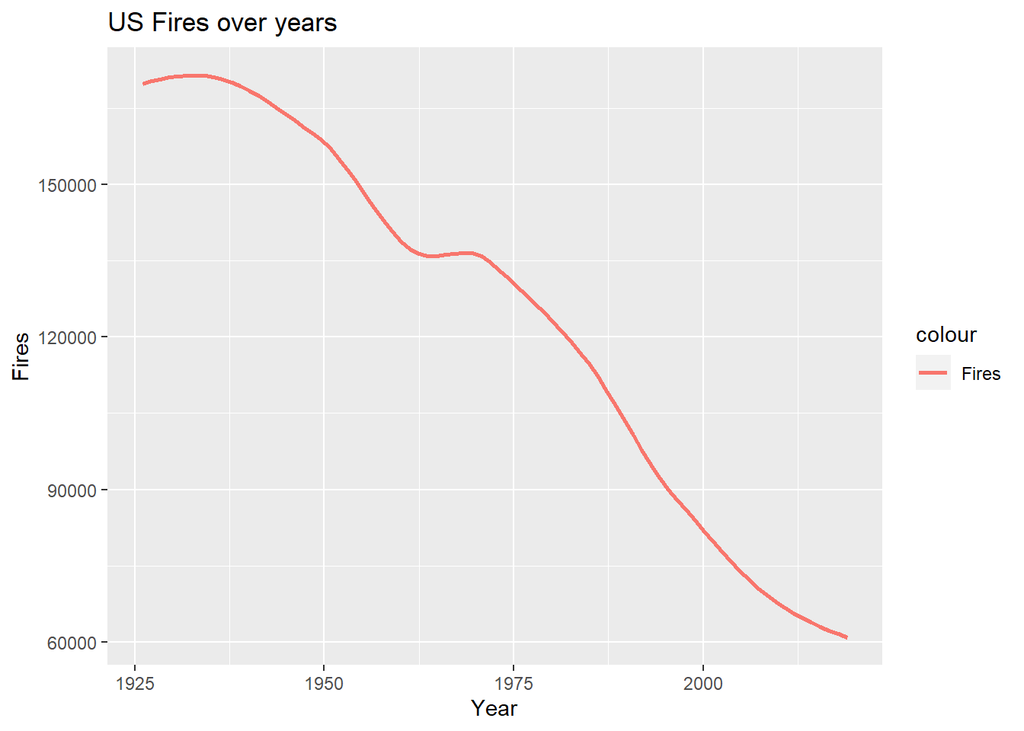

```r
ggplot()+
  geom_smooth(data = fire.data, se=FALSE, mapping = aes(x=Year, y=Fires, color = 'Fires'))+
  ggtitle("US Fires over years")
```

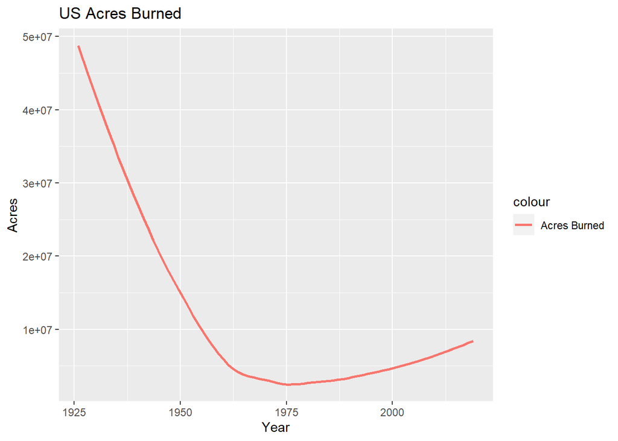

```r
ggplot()+
  geom_smooth(data = fire.data, se=FALSE, mapping = aes(x=Year, y=Acres, color = 'Acres Burned'))+
  ggtitle("US Acres Burned")
```

Though this data is only the United States, it is interesting seeing the dip end in 1975, and slowly go back up while the number of fires still goes down, it seems like the fires are just getting bigger in more recent years, but we have less fires starting overall.

```r
head(car.data)
```

```
## # A tibble: 4 x 3
##   car_type       pounds_of_c02 miles_driven
##   <chr>                  <dbl>        <dbl>
## 1 All Electric            4100        11824
## 2 Plug-in Hybrid          5885        11824
## 3 Hybrid                  6258        11824
## 4 Gasoline               11435        11824
```

```r
head(electric.data)
```

```
## # A tibble: 6 x 2
##   electric_sources percentage_grid
##   <chr>                      <dbl>
## 1 Natrual Gas                38.5
## 2 Coal                       23.5
## 3 Nuclear                    19.7
## 4 Wind                        7.31
## 5 Hydro                       6.54
## 6 Solar                       1.76
```

These last two data sets are just to fill in later when we look at renewable energy and what would happen if we managed to switch to a green house gas free life style which would include changing the power grid and switching to electric cars. This data set needs to be worked on with more tables if I pursue this path further.

# Data Science Questions

Looking at this initial data relating to each other with the whole world its co2 data, to just looking at the US to find a closer relation, it seems like deforestation might be promising to explore to see if that is more closely related to emissions.

I also want to look into GPD and co2 output as well, i think that they don’t have to be connected, but could also be in close relation when your economy is based off of machinery that isn’t the cleanest. For example a country that has a higher oil co2 release might have a higher GPD and be having more deforestation as well. This would all point to a mindset though rather than an actual mathematical pattern that you can follow.

I don’t think there are any ethical or social disadvantages to looking into this area and digging deeper into relations between the forests of our world and climate change. If anything, this research will end up pointing fingers and showing the countries that really need to get their act together and push society further along to improve itself.